# Temperature trends in Canberra, Australia

### matthew.bitters@colorado.edu

### 10/1/2025

This script downloads NCEI temperature data from the Canberra, Australia airport and makes some figures to evaluate trends over time.

## Australia is a special place for me

I completed my PhD work in Australia where I was based out of Canberra and a tiny town called Bombala in southeastern Australia. The timber industry is very prevalent in this area. In the 1980s, the state forest service cleared native Eucalyptus forest and replaced it with a Monterrey pine plantation for timber harvest. However, they left behind fragments of native forest of different sizes and distances to one another. I examined how species at high trophic levels in the invertebrate food web, e.g., predator ground beetles and nematode parasites, responded to habitat fragmentation and then wildfire.

In addition to habitat loss and fragmentation, southeastern Australia faces many threats including climate change. Habitat fragmentation can excerbate these threats by introducing more edge habitat and decreasing connectivity to larger, continuous habitats.

```python
# Import libraries
import earthpy # Manage local data
import pandas as pd
import hvplot.pandas
import holoviews as hv
import numpy as np
# Advanced options on matplotlib/seaborn/pandas plots
import matplotlib.pyplot as plt
# Common statistical plots for tabular data
import seaborn as sns
# Fit an OLS linear regression
from sklearn.linear_model import LinearRegression
```

**Data description** I accessed daily climate summaries data using the NCEI API for the Canberra Airport in Canberra, Australian Capitol Territory, Australia. The Global Historical Climatology Network (GHCN)-Daily dataset contains records from 80,000 stations across 180 countries and territories. Data collected includes maximum and minimum temperature, precipitation, snowfall, and snow depth. Most stations report precipitation only, however.

Menne, M. J., I. Durre, R. S. Vose, B. E. Gleason, & T. G. Houston (2012). An Overview of the Global Historical Climatology Network-Daily Database. Journal of Atmospheric and Oceanic Technology, 29, 897–910. https://doi.org/10.1175/JTECH-D-11-00103.1

The two code chunks below use the NCEI API to download maximum daily temperatures for the Canberra Airport for the entire period of record (1939-2010) and checks to make sure it actually downloaded.

```python
# url for Canberra airport - max temperature
can_url = ('https://www.ncei.noaa.gov/access/services/da'
'ta/v1?dataset=daily-summaries&dataTypes=TMAX&stations=ASN00070014&startDate=1939-03-01&endDate=2010-12-01&units=standard')
can_url
```

```
'https://www.ncei.noaa.gov/access/services/data/v1?dataset=daily-summaries&dataTypes=TMAX&stations=ASN00070014&startDate=1939-03-01&endDate=2010-12-01&units=standard'
```

```python
# Download the climate data
can_climate_df = pd.read_csv(
    can_url,
    index_col='DATE',
    parse_dates=True,
    na_values=['NaN']
)

# Check that the download worked
can_climate_df.head()
```

[output not shown]

[output cut: 60 more lines]

[output not shown]

After successfully downloading the data, I rename the maximum temperature column (TMAX) to something more meaningful. The initial data were in degrees Fahrenheit, so I then use a function to convert the column to degrees Celcius.

```python
# Rename max temp column (TMAX) to max_temp_f (deg f)
can_climate_df = can_climate_df.rename(columns={
    'TMAX': 'max_temp_f',
})
can_climate_df.head()
```

| DATE | STATION | max_temp_f |
| --- | --- | --- |
| 1939-03-01 | ASN00070014 | 75.0 |
| 1939-03-02 | ASN00070014 | 74.0 |
| 1939-03-03 | ASN00070014 | 74.0 |
| 1939-03-04 | ASN00070014 | 75.0 |
| 1939-03-05 | ASN00070014 | NaN |

```python
# Convert temp_f to temp_c using a function
def convert_temp_f_to_c(max_temp_f):
    """Convert Fahrenheit temperature to Celcius"""
    return (max_temp_f-32) * 5/9

# Use function
can_climate_df['max_temp_c'] = (
    can_climate_df['max_temp_f'].apply(convert_temp_f_to_c))

# Look at df
can_climate_df
```

| DATE | STATION | max_temp_f | max_temp_c |
| --- | --- | --- | --- |
| 1939-03-01 | ASN00070014 | 75.0 | 23.888889 |
| 1939-03-02 | ASN00070014 | 74.0 | 23.333333 |
| 1939-03-03 | ASN00070014 | 74.0 | 23.333333 |
| 1939-03-04 | ASN00070014 | 75.0 | 23.888889 |
| 1939-03-05 | ASN00070014 | NaN | NaN |
| ... | ... | ... | ... |
| 2010-11-27 | ASN00070014 | 82.0 | 27.777778 |
| 2010-11-28 | ASN00070014 | 66.0 | 18.888889 |
| 2010-11-29 | ASN00070014 | 61.0 | 16.111111 |
| 2010-11-30 | ASN00070014 | 63.0 | 17.222222 |
| 2010-12-01 | ASN00070014 | NaN | NaN |

26209 rows × 3 columns

Finally, I save the final data frame to my codespaces in case I need to come back to it without having re-download and re-convert temperatures.

```python
# Save the climate data
can_climate_df.to_csv('canberra_climate_data')
```

### Data exploration and visualization

First, I made a very basic plot of maximum daily temperatures over time. It's difficult to see any trends because the variation is so wide.

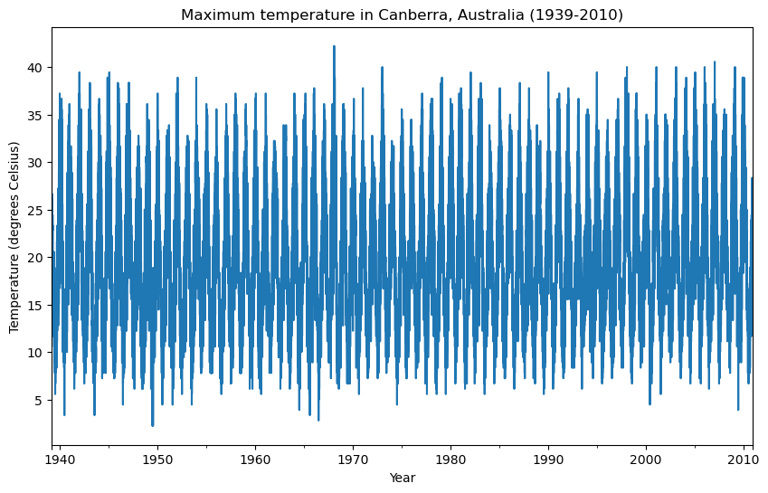

```python
# Make a basic plot
can_climate_df.plot(
    y = 'max_temp_c',
    title = 'Maximum temperature in Canberra, Australia (1939-2010)',
    xlabel = 'Year',
    ylabel = 'Temperature (degrees Celsius)',
    figsize = (10,6),
    legend = False)
```

```python
print(can_climate_df.columns)
```

```
Index(['STATION', 'max_temp_f', 'max_temp_c'], dtype='object')
```

Additionally to the large variation, and because maximum temperatures are inherently an extreme measurement, I summarized daily maximums to annual averages. This removes variation that is expected at the daily level. Now, I can look at trends over time, i.e., are maximum temperatures becoming warmer over time?

```python
# Summarize to annual average max temperature
can_ann_df = (
can_climate_df[['max_temp_f', 'max_temp_c']]
.resample('YS')
.mean()
)


can_ann_df
```

| DATE | max_temp_f | max_temp_c |
| --- | --- | --- |
| 1939-01-01 | 63.222951 | 17.346084 |
| 1940-01-01 | 69.548209 | 20.860116 |
| 1941-01-01 | 67.443526 | 19.690848 |
| 1942-01-01 | 67.526027 | 19.736682 |
| 1943-01-01 | 64.336111 | 17.964506 |
| ... | ... | ... |
| 2006-01-01 | 71.126027 | 21.736682 |
| 2007-01-01 | 70.161644 | 21.200913 |
| 2008-01-01 | 68.751366 | 20.417426 |
| 2009-01-01 | 70.326027 | 21.292237 |
| 2010-01-01 | 67.505988 | 19.725549 |

72 rows × 2 columns

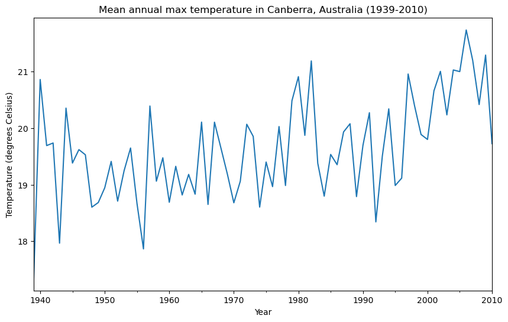

```python
# Plot the annual data
can_ann_df.plot(
    y = 'max_temp_c',
    title = 'Mean annual max temperature in Canberra, Australia (1939-2010)',
    xlabel = 'Year',
    ylabel = 'Temperature (degrees Celsius)',
    figsize = (10,6),
    legend = False)
```

```python
# Plot the annual data interactively
inter_canberra_annual_climate_plot = can_ann_df.hvplot(
    y = 'max_temp_c',
    title = 'Mean annual max temperature in Canberra, Australia (1939-2010)',
    xlabel = 'Year',
    ylabel = 'Temperature (°C)',
    figsize = (10,6),
    legend = False)

inter_canberra_annual_climate_plot
```

```
WARNING:param.main: hvPlot does not have the concept of a figure, and the figsize keyword will be ignored. The size of each subplot in a layout is set individually using the width and height options.
```

```python
# Save interactive annual plot
hv.save(inter_canberra_annual_climate_plot, 'inter_canberra_annual_climate_plot.html')
```

### Data analysis using an OLS linear regression

Next, I used an OLS linear regression to determine the rate of increase (i.e., the slope of the regression line). Maximum average annual temperatures are increasing by 0.02 degrees Celcius per year.

```python
# Fit an OLS linear regression


# Reset index so DATE is a column again
can_ann_df = can_ann_df.reset_index()

# Extract year
can_ann_df["year"] = can_ann_df["DATE"].dt.year

# Drop rows with missing temp values
can_ann_df = can_ann_df.dropna(subset=["max_temp_c"])

# Define predictors (X) and response (y)
X = can_ann_df["year"].values.reshape(-1, 1)   # sklearn needs 2D array
y = can_ann_df["max_temp_c"].values

# Fit linear regression
model = LinearRegression()
model.fit(X, y)

# Save coefficients
slope = model.coef_[0]
intercept = model.intercept_

# Print coefficients
print("Intercept (β0):", model.intercept_)
print("Slope (β1, °C per year):", model.coef_[0])
```

```
Intercept (β0): -23.865992429627404
Slope (β1, °C per year): 0.022028197784429066
```

Finally, I visualize results in a nice plot and make predictions into the future using the model. An important assumption when making these predictions is that the climate continues to warm at a consistent rate and other factors are not influencing the rising trend that we see. This assumption is likely not valid, but this is still a useful thought exercise (and good Python practice!).

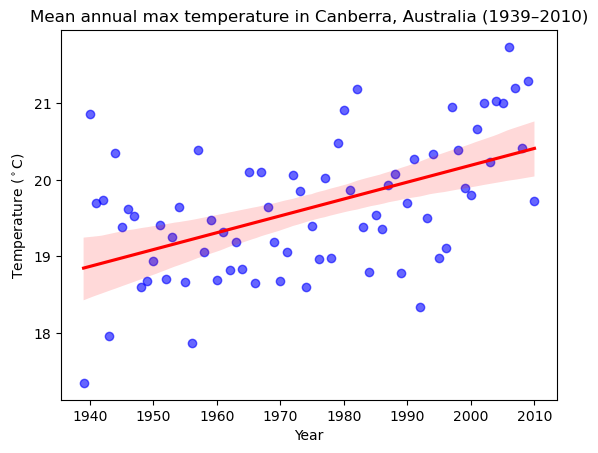

```python
# Plot annual average max temperature with a trend line and save figure
ax = sns.regplot(
    data=can_ann_df,
    x="year",
    y="max_temp_c",
    scatter_kws={"alpha": 0.6, "color": "blue"},
    line_kws={"color": "red"}
)

ax.set(
    title='Mean annual max temperature in Canberra, Australia (1939–2010)',
    xlabel='Year',
    ylabel='Temperature ($^\circ$C)'
)

# Save the figure via the Axes object
ax.figure.savefig("canberra_annual_max_temp.png", dpi=300, bbox_inches='tight')

plt.show()
```

```python
# Predict trend values for first and last year
first_year = can_ann_df["year"].min()
last_year = can_ann_df["year"].max()

temp_first = model.predict([[first_year]])[0]
temp_last = model.predict([[last_year]])[0]

# Difference over the period
temp_change = temp_last - temp_first

print(f"Predicted temperature in {first_year}: {temp_first:.2f}°C")
print(f"Predicted temperature in {last_year}: {temp_last:.2f}°C")
print(f"Change over the period: {temp_change:.2f}°C")

# Predict temperature in 2050
year_2050 = 2050
temp_2050 = model.predict([[year_2050]])[0]

print(f"Predicted temperature in {year_2050}: {temp_2050:.2f}°C")
```

[output not shown]

### Conclusions

According to the New South Wales government, by 2050, the predicted average temperature in the Australian Capital Territory (ACT) is expected to be 1.1°C higher than it is now under a low-emissions scenario and 1.8°C higher under a high-emissions scenario, which means my model actually underestimates the effects of climate change. Remarkably, the ACT is already 100% powered by renewable energy and has multiple climate change, infrastructure, and integrated energy strategies going into the future. Notably, targets include achieving 30% canopy cover and 30% surface permeability across Canberra's urban areas by 2045.

Similiar to the United States, climate change has contributed to unprecedented wildfires, heatwaves, floods, droughts, and climate-related infectious diseases across Australia. While climate-forward looking strategies are important, it is crucial to develop some of these strategies into actions to address climate change impacts.

NSW Government. (2025) https://www.climatechange.environment.nsw.gov.au/my-region/act-region

Xu et al. (2023) Climate change, environmental extremes, and human health in Australia: challenges, adaptation strategies, and policy gaps. The Lancet Regional Health - Western Pacific, 40, 100936. https://doi.org/10.1016/j.lanwpc.2023.100936